# Project 2: Data Mining, Classification, Prediction

SDS322E

# Mining, Classification, Prediction

## Sean Davis smd3484

### Introduction

I initially wanted to use my previous data sets with S&P 500 and Avocados, but I had trouble coming up with a clear binary variable that might provide some interesting conclusions. So for this project, I found something a bit more friendly on Kaggle. This data set is called Customer Personality Analysis. It is described as “a detailed analysis of a company’s ideal customers that helps a business to better understand its customers and makes it easier for them to modify products according to their specific needs, behaviors and concerns.” I decided I wanted to see if I could find any relations between the amount of wine bought or `MntWine`, `Income`, `Age`, and my created binary variable `HasKids` along with all the other numeric variables given in this data set. Note: `HasKids` means that the customers have kids or teens living at home, so some of the data for older customers will not represent whether they actually have kids that are grown.

People

ID: Customer’s unique identifier  
Year_Birth: Customer’s birth year  
Education: Customer’s education level  
Marital_Status: Customer’s marital status  
Income: Customer’s yearly household income  
Kidhome: Number of children in customer’s household  
Teenhome: Number of teenagers in customer’s household  
Dt_Customer: Date of customer’s enrollment with the company  
Recency: Number of days since customer’s last purchase  
Complain: 1 if the customer complained in the last 2 years, 0 otherwise

Products

MntWines: Amount spent on wine in last 2 years  
MntFruits: Amount spent on fruits in last 2 years  
MntMeatProducts: Amount spent on meat in last 2 years  
MntFishProducts: Amount spent on fish in last 2 years  
MntSweetProducts: Amount spent on sweets in last 2 years  
MntGoldProds: Amount spent on gold in last 2 years

Promotion

NumDealsPurchases: Number of purchases made with a discount  
AcceptedCmp1: 1 if customer accepted the offer in the 1st campaign, 0 otherwise  
AcceptedCmp2: 1 if customer accepted the offer in the 2nd campaign, 0 otherwise  
AcceptedCmp3: 1 if customer accepted the offer in the 3rd campaign, 0 otherwise  
AcceptedCmp4: 1 if customer accepted the offer in the 4th campaign, 0 otherwise  
AcceptedCmp5: 1 if customer accepted the offer in the 5th campaign, 0 otherwise  
Response: 1 if customer accepted the offer in the last campaign, 0 otherwise

Place

NumWebPurchases: Number of purchases made through the company’s website  
NumCatalogPurchases: Number of purchases made using a catalogue  
NumStorePurchases: Number of purchases made directly in stores  
NumWebVisitsMonth: Number of visits to company’s website in the last month

```r
library(tidyverse)
customers = read.table("~/project2/marketing_campaign.csv", sep = "\t",
    header = T)

# Trimming some of the Fat
customers <- customers %>% mutate(TotalPurchases = NumWebPurchases +
    NumCatalogPurchases + NumStorePurchases)
customers <- customers %>% na.omit

# Making my Binary variables.
customers$IsSingle = ifelse(customers$Marital_Status %in% c("Widow",
    "Single", "Divorced"), 1, 0)
customers$HasKids = ifelse(customers$Kidhome > 0 | customers$Teenhome >
    0, 1, 0)

# Making an easier variable to analyze for age.
customers$Age = 2016 - customers$Year_Birth

# Making a more friendly dataset for our clustering.
clustFriendly <- customers %>% select(c(Age, Income, TotalPurchases,
    MntWines))
customers$HasKids = ifelse(customers$Kidhome > 0 | customers$Teenhome >
    0, 1, 0)

# Scaling my DataSet
scaledClustFriendly <- scale(clustFriendly)
```

### Cluster Analysis

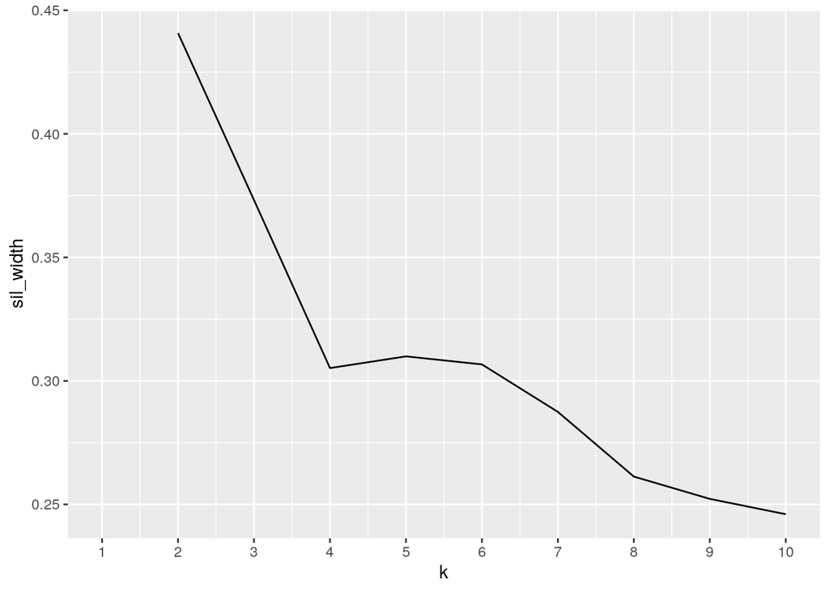

```r
library(cluster)

## Finding out best k value with sil width
sil_width <- vector()
for (i in 2:10) {
    kms <- kmeans(scaledClustFriendly, centers = i)
    sil <- silhouette(kms$cluster, dist(scaledClustFriendly))
    sil_width[i] <- mean(sil[, 3])
}

ggplot() + geom_line(aes(x = 1:10, y = sil_width)) + scale_x_continuous(name = "k",
    breaks = 1:10)
```

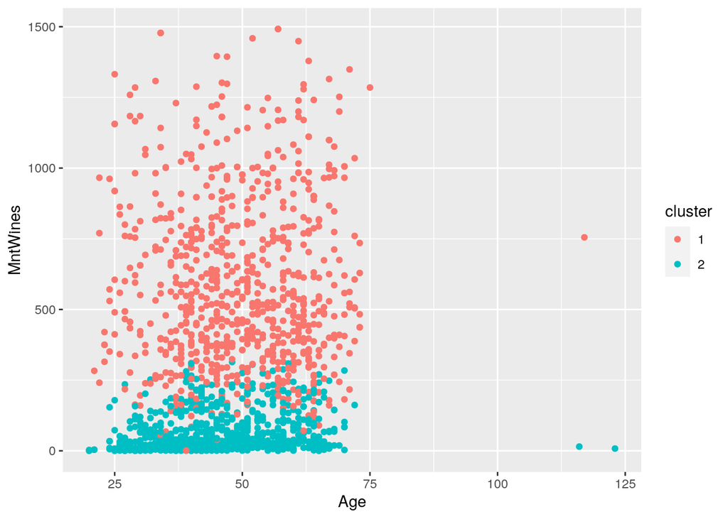

```r
pamResult <- pam(scaledClustFriendly, k = 2)


pamClust <- clustFriendly %>% mutate(cluster = as.factor(pamResult$clustering))

## Visualizing Clusters
pamClust %>% ggplot(aes(Age, MntWines, color = cluster)) + geom_point()
```

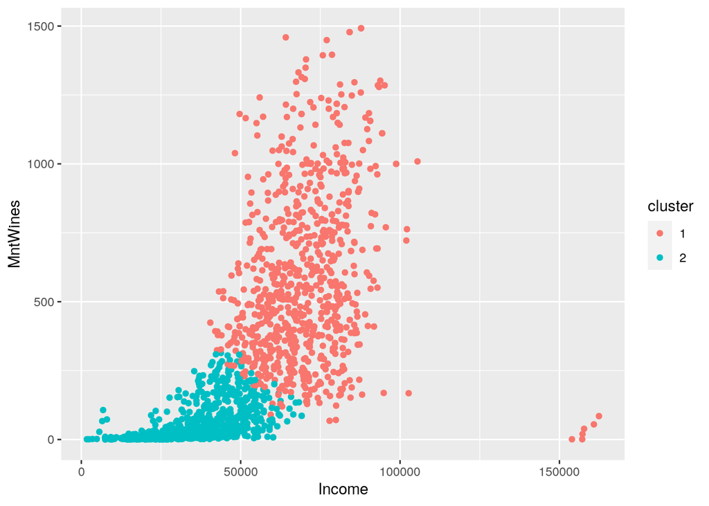

```r
pamClust %>% ggplot(aes(Income, MntWines, color = cluster)) +
    geom_point()
```

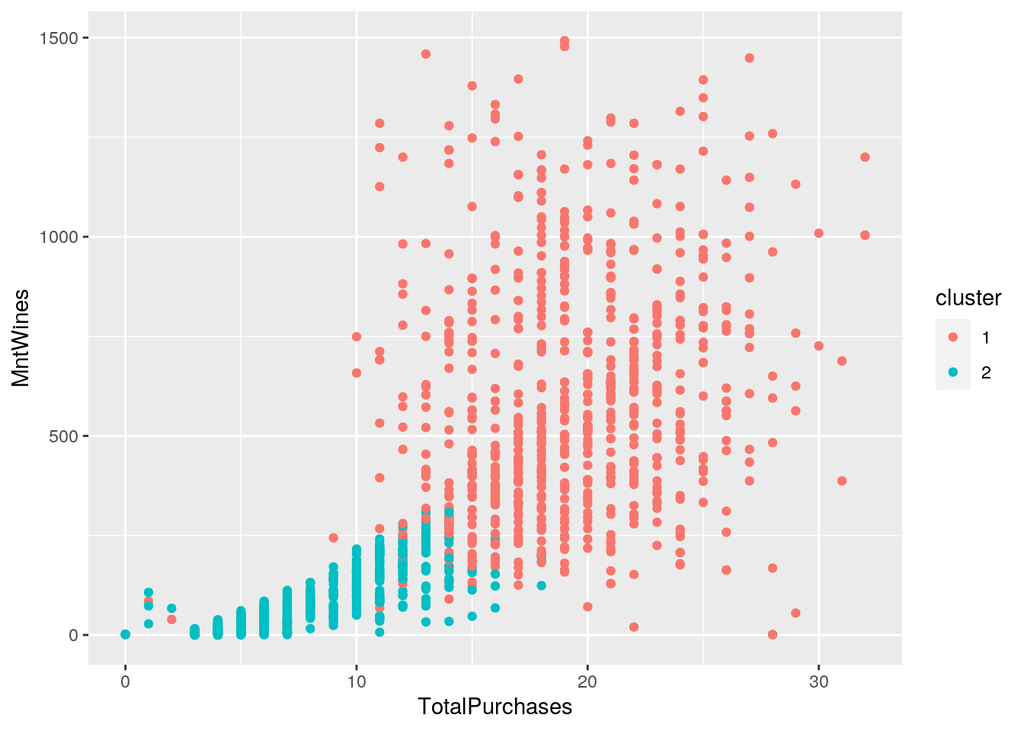

```r
pamClust %>% ggplot(aes(TotalPurchases, MntWines, color = cluster)) +
    geom_point()
```

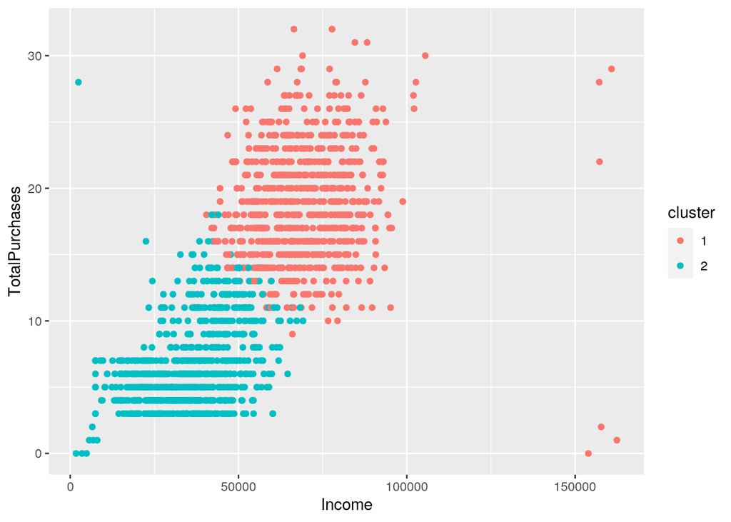

```r
pamClust %>% ggplot(aes(Income, TotalPurchases, color = cluster)) +
    geom_point()
```

So I was hoping to find some relation between age and the amount of wine purchases, but they seem pretty independent of one another. I think the clusters are forming more around income and amount of purchases, including wine. I tried these clusters before scaling, and it showed a pretty clear dividing line showed around the 50000 income mark on our clusters. After scaling, the line got a bit blurred, but it is pretty similar regardless. I would say that based on this clustering the correlation seems to be most prevalent between how much money customers makes and how much they spend on wine. Shocking, I know.

### Dimensionality Reduction with PCA

```r
custPCA <- princomp(scaledClustFriendly)

summary(custPCA, loadings = T)
```

```
## Importance of components:
##                           Comp.1    Comp.2     Comp.3     Comp.4
## Standard deviation     1.5882222 0.9671661 0.55924013 0.47647136
## Proportion of Variance 0.6309856 0.2339909 0.07823365 0.05678982
## Cumulative Proportion  0.6309856 0.8649765 0.94321018 1.00000000
##
## Loadings:
##                Comp.1 Comp.2 Comp.3 Comp.4
## Age             0.202  0.979
## Income          0.560        -0.749 -0.344
## TotalPurchases  0.575 -0.130         0.804
## MntWines        0.561 -0.132  0.658 -0.485
```

```r
eigval <- custPCA$sdev^2  #square to convert SDs to eigenvalues
varprop = round(eigval/sum(eigval), 2)

round(cumsum(eigval)/sum(eigval), 2)
```

```
## Comp.1 Comp.2 Comp.3 Comp.4
##   0.63   0.86   0.94   1.00
```

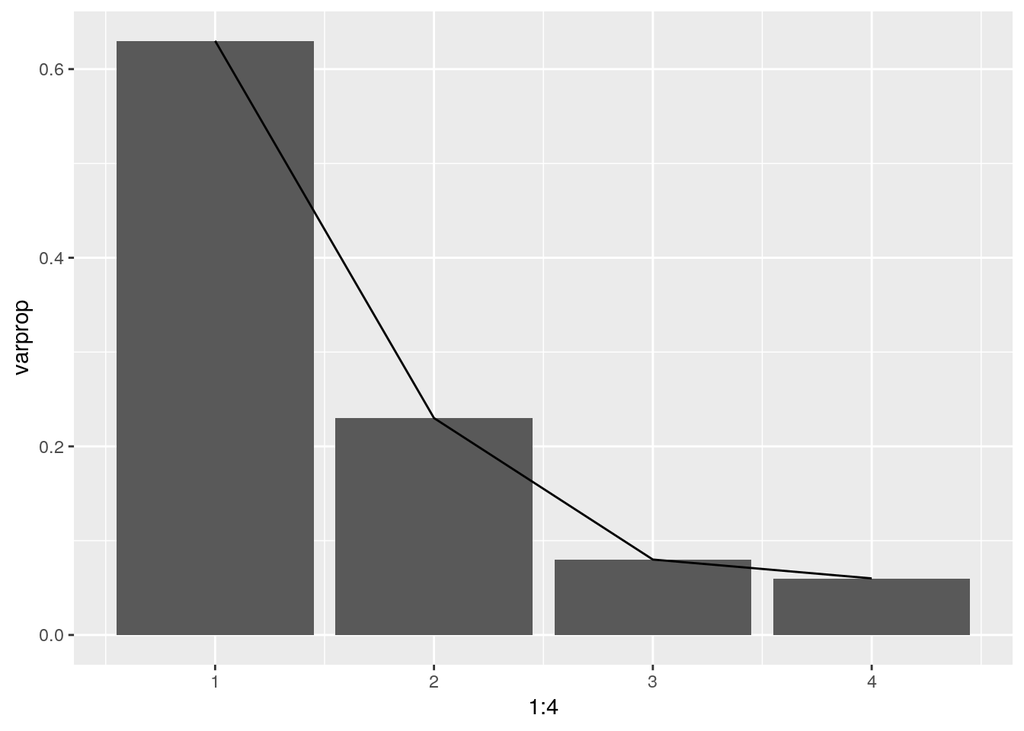

```r
ggplot() + geom_bar(aes(y = varprop, x = 1:4), stat = "identity") +
    geom_path(aes(y = varprop, x = 1:4))
```

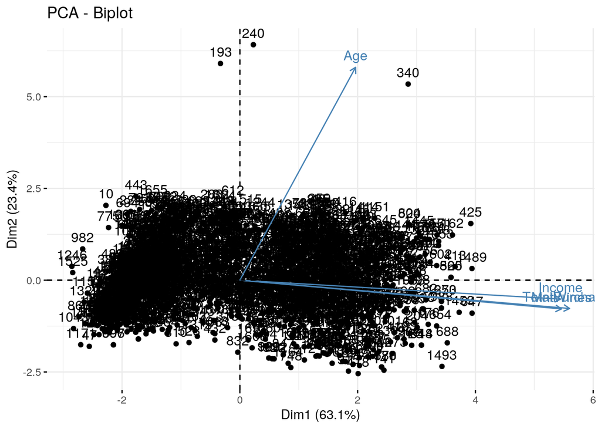

```r
# so 2 PCs


library(factoextra)
fviz_pca_biplot(custPCA)
```

Similar to what we discussed before, PC1 shows some pretty positive correlation between the amount of money spent on wine, the total purchases made, and the income of an individual. There is a very slight positive correlation between age and the other values, but it is almost negligible. PC2 demonstrates a slight negative correlation between age, total purchases, and amount spent on wine. The total cumulative proportion of variance at PC2 is 86% of the total variance.

### Linear Classifier

```r
## Making a numerical Dataset from the original customers df
## without many of the redundant and superfluous data points
## like the ones associated with promotions.

linCuts <- customers %>% select(is.numeric) %>% select(-c(ID,
    Year_Birth, Kidhome, Teenhome, Recency, MntGoldProds, TotalPurchases)) %>%
    select(-c(12:18))

library(caret)

fit <- glm(HasKids ~ ., data = linCuts, family = "binomial")
score <- predict(fit, linCuts)
class_diag(score, linCuts$HasKids, positive = 1)
```

```
##            acc   sens   spec    ppv     f1     ba    auc
## Metrics 0.8918 0.9302 0.7971 0.9187 0.9244 0.8637 0.9483
```

```r
table(truth = factor(linCuts$HasKids == 1, levels = c("TRUE",
    "FALSE")), prediction = factor(score[] > 0.5, levels = c("TRUE",
    "FALSE")))
```

```
##        prediction
## truth   TRUE FALSE
##   TRUE  1119    84
##   FALSE   99   389
```

```r
set.seed(2222)
cv <- trainControl(method = "cv", number = 5, classProbs = T,
    savePredictions = T)
fit <- train(HasKids ~ ., data = linCuts, trControl = cv, method = "glm")
class_diag(fit$pred$pred, fit$pred$obs, positive = 1)
```

```
##            acc   sens   spec    ppv     f1     ba    auc
## Metrics 0.8699 0.9534 0.6639 0.8749 0.9125 0.8087 0.9237
```

So this model is trying to predict whether or not the customer has kids at home based on all the other variables in the data set. The model is predicting decently well with an area under the curve of .9237 after cross validation. There are signs of overfitting since the AUC is a tad lower after CV, but overall I think it is an okay model for predicting whether the customer has kids at home.

### Non-Parametric Classifier

```r
library(caret)
knn_fit <- knn3(factor(HasKids == 1, levels = c("TRUE", "FALSE")) ~
    ., data = linCuts, k = 5)
y_hat_knn <- predict(knn_fit, linCuts)


class_diag(y_hat_knn[, 1], linCuts$HasKids, positive = 1)
```

```
##           acc   sens   spec    ppv     f1     ba   auc
## Metrics 0.861 0.9468 0.6496 0.8695 0.9065 0.7982 0.926
```

```r
table(truth = factor(linCuts$HasKids == 1, levels = c("TRUE",
    "FALSE")), prediction = factor(y_hat_knn[, 1] > 0.5, levels = c("TRUE",
    "FALSE")))
```

```
##        prediction
## truth   TRUE FALSE
##   TRUE  1139    64
##   FALSE  171   317
```

```r
set.seed(2222)
cv <- trainControl(method = "cv", number = 5, classProbs = T,
    savePredictions = T)
fit <- train(HasKids ~ ., data = linCuts, trControl = cv, method = "knn")
class_diag(fit$pred$pred, fit$pred$obs, positive = 1)
```

```
##            acc   sens   spec    ppv    f1     ba    auc
## Metrics 0.8161 0.9135 0.5758 0.8415 0.876 0.7447 0.8194
```

So this model seems to be much worse at predicting whether the customer has kids at home based on the AUC of .8194. There also seems to be a huge case of overfitting since the difference between the initial AUC and the CV AUC is quite large from .926 to .819. I would say that the linear model does a better job at predicting in this case.

### Regression/Numeric Prediction

```r
fit <- lm(Age ~ ., data = linCuts)
yhat <- predict(fit)
mean((linCuts$Age - yhat)^2)
```

```
## [1] 132.9645
```

```r
set.seed(1234)
k = 5
data <- linCuts[sample(nrow(linCuts)), ]
folds <- cut(seq(1:nrow(linCuts)), breaks = k, labels = F)
diags <- NULL
for (i in 1:k) {
    train <- data[folds != i, ]
    test <- data[folds == i, ]

    fit <- lm(Age ~ ., data = train)

    yhat <- predict(fit, newdata = test)

    diags <- mean((test$Age - yhat)^2)
}
mean(diags)
```

```
## [1] 129.7438
```

For this model I’m trying to predict Age from the other numeric variables in the data set. Truthfully, I have a hard time interpreting MSE, but I would say that the values around 130 seem quite large. So I don’t think this model is doing the best job at predicting our age of customers. But the MSE is lower in the CV, so I believe the model is not overfitting at all.

### Python

```r
library(reticulate)
```

```python
pyCust = r.customers
pyCust.Education = pyCust.Education.str.upper()
pyCust
```

```
##          ID  Year_Birth   Education  ...  IsSingle  HasKids   Age
## 0      5524        1957  GRADUATION  ...       1.0      0.0  59.0
## 1      2174        1954  GRADUATION  ...       1.0      1.0  62.0
## 2      4141        1965  GRADUATION  ...       0.0      0.0  51.0
## 3      6182        1984  GRADUATION  ...       0.0      1.0  32.0
## 4      5324        1981         PHD  ...       0.0      1.0  35.0
## 5      7446        1967      MASTER  ...       0.0      1.0  49.0
## 6       965        1971  GRADUATION  ...       1.0      1.0  45.0
## 7      6177        1985         PHD  ...       0.0      1.0  31.0
## 8      4855        1974         PHD  ...       0.0      1.0  42.0
## 9      5899        1950         PHD  ...       0.0      1.0  66.0
## 10      387        1976       BASIC  ...       0.0      0.0  40.0
## 11     2125        1959  GRADUATION  ...       1.0      0.0  57.0
## 12     8180        1952      MASTER  ...       1.0      1.0  64.0
## 13     2569        1987  GRADUATION  ...       0.0      0.0  29.0
```

[output cut: 49 more lines]

```r
customers <- py$pyCust
customers
```

```
##     ID Year_Birth  Education Marital_Status Income Kidhome Teenhome Dt_Customer
## 1 5524       1957 GRADUATION         Single  58138       0        0  04-09-2012
## 2 2174       1954 GRADUATION         Single  46344       1        1  08-03-2014
## 3 4141       1965 GRADUATION       Together  71613       0        0  21-08-2013
##   Recency MntWines MntFruits MntMeatProducts MntFishProducts MntSweetProducts
## 1      58      635        88             546             172               88
## 2      38       11         1               6               2                1
## 3      26      426        49             127             111               21
##   MntGoldProds NumDealsPurchases NumWebPurchases NumCatalogPurchases
## 1           88                 3               8                  10
## 2            6                 2               1                   1
## 3           42                 1               8                   2
##   NumStorePurchases NumWebVisitsMonth AcceptedCmp3 AcceptedCmp4 AcceptedCmp5
## 1                 4                 7            0            0            0
## 2                 2                 5            0            0            0
## 3                10                 4            0            0            0
##   AcceptedCmp1 AcceptedCmp2 Complain Z_CostContact Z_Revenue Response
## 1            0            0        0             3        11        1
## 2            0            0        0             3        11        0
## 3            0            0        0             3        11        0
##   TotalPurchases IsSingle HasKids Age
## 1             22        1       0  59
## 2              4        1       1  62
## 3             20        0       0  51
##  [ reached 'max' / getOption("max.print") -- omitted 1688 rows ]
```

Here I simply interpreted our data set in python and then changed the Education column to all uppercase and then interpreted that data set back into our original r data set. Pretty useful tool.

### Concluding Remarks

I understand the power that these models have and see the utility that they have in the real world. I am excited to understand them better and do more projects independently like this in the future. Thanks for the great class!